# Assign4

**Importing reuquired python packages**

```python
import tensorflow as tf

#We need to import the following
import numpy as np
import matplotlib.pyplot as plt
from tensorflow.keras.layers import Input, Conv2D, Dense, Flatten, Dropout, GlobalMaxPooling2D, MaxPooling2D, BatchNormalization
from tensorflow.keras.models import Model
from tensorflow.keras.preprocessing.image import ImageDataGenerator
```

**Loading MNIST dataset, normalizing values to be between 0 and 1, and finally reshaping for adding 3rd dimension.**

```python
# Load the data
mnist = tf.keras.datasets.mnist
(x_train, y_train), (x_test, y_test) = mnist.load_data()

#Normalizing
x_train, x_test = x_train / 255.0, x_test / 255.0

print("x_train.shape:", x_train.shape)
print("x_test.shape:", x_test.shape)

#Changing the shape of data to 3D
# the data is only 2D! make it 60000 * 28 * 28 * 1
# convolution expects height x width x color
x_train = np.expand_dims(x_train, -1)
x_test = np.expand_dims(x_test, -1)
print(x_train.shape)
```

```
Downloading data from https://storage.googleapis.com/tensorflow/tf-keras-datasets/mnist.npz
x_train.shape: (60000, 28, 28)
x_test.shape: (10000, 28, 28)
(60000, 28, 28, 1)
```

**Number of target classes**

```python
# number of classes
K = len(set(y_train))
print("number of classes:", K)
```

```
number of classes: 10
```

**Builiding functions for model compilation, loss plots, confusion matrix, showing missclassified images.**

Function for model compilation

```python
def compile_model(model):
  # Compile and fit
  model.compile(optimizer='adam',
                loss='sparse_categorical_crossentropy',
                metrics=['accuracy'])
  r = model.fit(x_train, y_train, validation_data=(x_test, y_test), epochs=15)
  return r
```

Function for loss and accuracy plots.

```python
def create_loss_plot_per_iteration(r):
  # Plot loss per iteration
  import matplotlib.pyplot as plt
  plt.plot(r.history['loss'], label='loss')
  plt.plot(r.history['val_loss'], label='val_loss')
  plt.legend()

def create_accuracy_plot_per_iteration(r):
  # Plot accuracy per iteration
  plt.plot(r.history['accuracy'], label='acc')
  plt.plot(r.history['val_accuracy'], label='val_acc')
  plt.legend()
```

Function for confusion matrix

```python
def get_confusion_matrix(model):
 # Evaluate the model
  print(model.evaluate(x_test, y_test))
  #Confusion Matrix
  from sklearn.metrics import confusion_matrix
  y_pred = model.predict(x_test).argmax(axis=1)
  cm = confusion_matrix(y_test, y_pred)
  print("               Predicted Label")
  print(cm)
  return y_pred
```

Function for showing missclassified images

```python
def show_missclassified_images(y_pred):
  # Show some misclassified examples
  misclassified_idx = np.where(y_pred != y_test)[0]
  i = np.random.choice(misclassified_idx)
  plt.imshow(x_test[i].reshape(28,28), cmap='gray')
  plt.title("True label: %s Predicted: %s" % (y_test[i], y_pred[i]))
```

**CNN Models - Conv-Pool**

**Model 1 - one conv-pool (i.e. convolution followed by max pooling)**

```python
from typing import Sized
# 32 - No of feature maps (changes with each conv layer)
# MaxPolling2D
# When we go from input layer to first ouput the depth is 1
# 3,3 - filter Size
# padding = same (no padding)

# Stage1
i = Input(shape=x_train[0].shape)
x = Conv2D(32, (3, 3), activation='relu', padding='same')(i)
x = MaxPooling2D((2,2))(x)

#Stage2
x = Flatten()(x)
x = Dense(512, activation='relu')(x)
x = Dense(K, activation='softmax')(x)

model1 = Model(i, x)

model1.summary()
```

```
Model: "model"
_________________________________________________________________
 Layer (type)                Output Shape              Param #
=================================================================
 input_1 (InputLayer)        [(None, 28, 28, 1)]       0

 conv2d (Conv2D)             (None, 28, 28, 32)        320

 max_pooling2d (MaxPooling2D  (None, 14, 14, 32)       0
 )

 flatten (Flatten)           (None, 6272)              0

 dense (Dense)               (None, 512)               3211776

 dense_1 (Dense)             (None, 10)                5130

=================================================================
Total params: 3,217,226
Trainable params: 3,217,226
Non-trainable params: 0
_________________________________________________________________
```

Model compilation and loss/accuracy plots

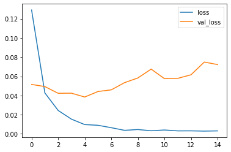

```python
# Model compile and fit
r1 = compile_model(model1)

# Loss plot
create_loss_plot_per_iteration(r1)
```

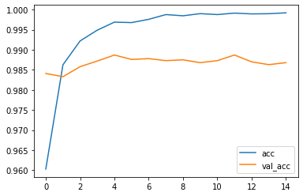

```python
# Accuracy plot
create_accuracy_plot_per_iteration(r1)
```

Confusion matrix and missclassfied examples

```python
y_pred = get_confusion_matrix(model1)
```

```
[0.07226797193288803, 0.9868000149726868]
               Predicted Label
[[ 971    1    1    1    0    1    2    1    1    1]
 [   2 1124    3    0    0    0    3    2    1    0]
 [   0    0 1021    2    1    0    0    6    2    0]
 [   0    0    0 1000    0    4    0    4    2    0]
 [   0    0    1    0  968    0    2    0    0   11]
 [   0    0    0   10    0  881    1    0    0    0]
 [   4    2    1    0    4    5  941    0    1    0]
 [   0    2    4    1    1    0    0 1015    1    4]
 [   1    0    2    5    0    2    2    4  952    6]
 [   0    1    0    1    4    2    0    0    6  995]]
```

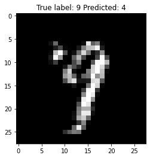

```python
# Show missclassified examples
show_missclassified_images(y_pred)
```

**Model 2 - two conv-pools**

```python
from typing import Sized
# 64 - No of feature maps (changes with each conv layer)
# MaxPolling2D
# When we go from input layer to first ouput the depth is 1
# 5,5 - filter Size
# padding = same (no padding)

# Stage1
i = Input(shape=x_train[0].shape)
x = Conv2D(32, (5, 5), activation='relu', padding='same')(i)
x = MaxPooling2D((2,2))(x)
x = Conv2D(64, (5, 5), activation='relu', padding='same')(x)
x = MaxPooling2D((2,2))(x)

#Stage2
x = Flatten()(x)
x = Dense(512, activation='relu')(x)
x = Dense(K, activation='softmax')(x)

model2 = Model(i, x)

model2.summary()
```

```
Model: "model_1"
_________________________________________________________________
 Layer (type)                Output Shape              Param #
=================================================================
 input_2 (InputLayer)        [(None, 28, 28, 1)]       0

 conv2d_1 (Conv2D)           (None, 28, 28, 32)        832

 max_pooling2d_1 (MaxPooling  (None, 14, 14, 32)       0
 2D)

 conv2d_2 (Conv2D)           (None, 14, 14, 64)        51264

 max_pooling2d_2 (MaxPooling  (None, 7, 7, 64)         0
 2D)

 flatten_1 (Flatten)         (None, 3136)              0

 dense_2 (Dense)             (None, 512)               1606144

 dense_3 (Dense)             (None, 10)                5130

=================================================================
Total params: 1,663,370
Trainable params: 1,663,370
Non-trainable params: 0
_________________________________________________________________
```

Model compilation and loss/accuracy plots

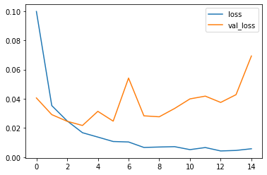

```python
# Model compile and fit
r2 = compile_model(model2)

# Loss plot
create_loss_plot_per_iteration(r2)
```

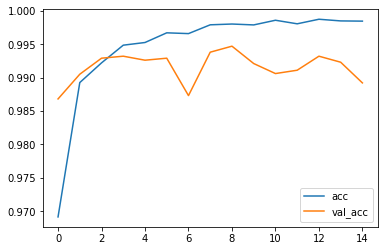

```python
# Accuracy plot
create_accuracy_plot_per_iteration(r2)
```

Confusion matrix and missclassfied examples

```python
y_pred = get_confusion_matrix(model2)
```

```
[0.06925974041223526, 0.9891999959945679]
               Predicted Label
[[ 977    0    0    0    0    0    0    1    1    1]
 [   0 1131    1    2    0    0    0    0    1    0]
 [   0    2 1028    0    1    0    0    1    0    0]
 [   0    0    2 1008    0    0    0    0    0    0]
 [   0    2    2    0  975    0    0    1    0    2]
 [   0    1    0   13    0  873    4    0    1    0]
 [   3    4    0    0    4    2  940    0    5    0]
 [   0    2    5    1    0    0    0 1017    2    1]
 [   1    0    3    2    0    0    0    0  968    0]
 [   0    1    2    6    9    8    0    5    3  975]]
```

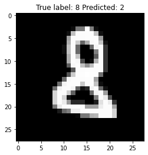

```python
# Show missclassified examples
show_missclassified_images(y_pred)
```

**Model 2 summary:** Model 2 with convoloution layer and maxpooling gives test accuracy of 98.92% with reduced validation loss at 0.069. As per loss plot, trainining loss starts plateauing from 4th epoch but validation loss starts increasing, hence model is becoming overfit. As per accuracy plot, both training and validation accuracy starts plateauing from 4th epoch. Hence, to reduce overfitness it can be stopped at 4-5 epoch.

**Model 3 - Multiple conv-pool layers, Dropouts.**

```python
from typing import Sized
# 256 - No of feature maps (changes with each conv layer)
# MaxPolling2D
# 3,3 - filter Size
# padding = same (no padding)

# Stage1
i = Input(shape=x_train[0].shape)
x = Conv2D(32, (3, 3), activation='relu', padding='same')(i)
x = MaxPooling2D((2,2))(x)
x = Conv2D(64, (3, 3), activation='relu', padding='same')(x)
x = MaxPooling2D((2,2))(x)
x = Conv2D(128, (3, 3), activation='relu', padding='same')(x)
x = MaxPooling2D((2,2))(x)
x = Conv2D(256, (3, 3), activation='relu', padding='same')(x)
x = MaxPooling2D((2,2))(x)

#Stage2
x = Flatten()(x)
x = Dropout(0.2)(x)
x = Dense(512, activation='relu')(x)
x = Dropout(0.2)(x)
x = Dense(K, activation='softmax')(x)

model3 = Model(i, x)

model3.summary()
```

```
Model: "model_2"
_________________________________________________________________
 Layer (type)                Output Shape              Param #
=================================================================
 input_3 (InputLayer)        [(None, 28, 28, 1)]       0

 conv2d_3 (Conv2D)           (None, 28, 28, 32)        320

 max_pooling2d_3 (MaxPooling  (None, 14, 14, 32)       0
 2D)

 conv2d_4 (Conv2D)           (None, 14, 14, 64)        18496

 max_pooling2d_4 (MaxPooling  (None, 7, 7, 64)         0
 2D)

 conv2d_5 (Conv2D)           (None, 7, 7, 128)         73856

 max_pooling2d_5 (MaxPooling  (None, 3, 3, 128)        0
 2D)

 conv2d_6 (Conv2D)           (None, 3, 3, 256)         295168

 max_pooling2d_6 (MaxPooling  (None, 1, 1, 256)        0
 2D)

 flatten_2 (Flatten)         (None, 256)               0

 dropout (Dropout)           (None, 256)               0

 dense_4 (Dense)             (None, 512)               131584

 dropout_1 (Dropout)         (None, 512)               0

 dense_5 (Dense)             (None, 10)                5130

=================================================================
Total params: 524,554
Trainable params: 524,554
Non-trainable params: 0
_________________________________________________________________
```

Model compilation and loss/accuracy plots

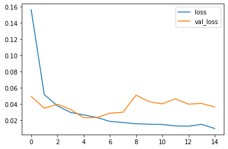

```python
# Model compile and fit
r3 = compile_model(model3)

# Loss plot
create_loss_plot_per_iteration(r3)
```

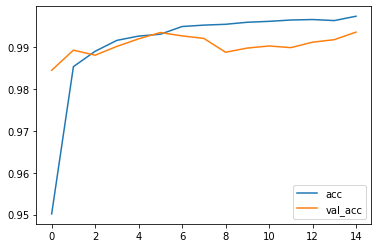

```python
# Accuracy plot
create_accuracy_plot_per_iteration(r3)
```

Confusion matrix and missclassfied examples

```python
y_pred = get_confusion_matrix(model3)
```

```
[0.03597318381071091, 0.9934999942779541]
               Predicted Label
[[ 974    0    2    0    0    0    0    0    2    2]
 [   0 1135    0    0    0    0    0    0    0    0]
 [   0    1 1031    0    0    0    0    0    0    0]
 [   0    0    1 1007    0    1    0    0    0    1]
 [   0    0    1    0  970    0    2    0    0    9]
 [   0    0    0    5    0  886    1    0    0    0]
 [   1    2    1    0    2    2  947    0    3    0]
 [   0    4    4    0    0    0    0 1018    0    2]
 [   0    1    1    2    0    0    0    0  969    1]
 [   0    0    0    0    4    4    0    3    0  998]]
```

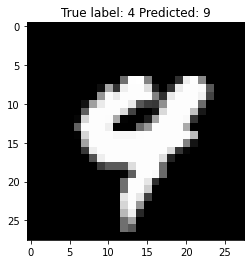

```python
# Show missclassified examples
show_missclassified_images(y_pred)
```

**Model 3 summary:** Model 3 with convoloution layer and maxpooling gives test accuracy of 99.35% with minimum loss at 0.036. As per loss plot, trainining loss and validation loass starts plateauing from 2nd epoch hence model 3 is more generalized as compared to model 1 and model 2. As per accuracy plot, both training and validation accuracy starts plateauing from 2nd epoch.

Model 3 is more generalized as compared model 1 and model 2 with loss reduced further at 0.03, accuracy and loss curves are also more smoother.

**Strid Conv models**

**Model 4 - CNN with one strided convolution layer**

```python
from typing import Sized
# 32 - No of feature maps (changes with each conv layer)
# MaxPolling2D
# When we go from input layer to first ouput the depth is 1
# 3,3 - filter Size
# padding = same (no padding)

# Stage1
i = Input(shape=x_train[0].shape)
x = Conv2D(64,(3, 3),strides = 2, activation='relu', padding='same')(i)

#Stage2
x = Flatten()(x)
x = Dense(512, activation='relu')(x)
x = Dense(K, activation='softmax')(x)

model4 = Model(i, x)

model4.summary()
```

```
Model: "model_3"
_________________________________________________________________
 Layer (type)                Output Shape              Param #
=================================================================
 input_4 (InputLayer)        [(None, 28, 28, 1)]       0

 conv2d_7 (Conv2D)           (None, 14, 14, 64)        640

 flatten_3 (Flatten)         (None, 12544)             0

 dense_6 (Dense)             (None, 512)               6423040

 dense_7 (Dense)             (None, 10)                5130

=================================================================
Total params: 6,428,810
Trainable params: 6,428,810
Non-trainable params: 0
_________________________________________________________________
```

Model compilation and loss/accuracy plots

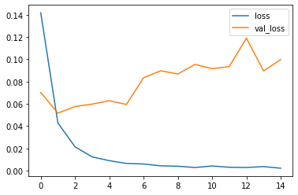

```python
# Model compile and fit
r4 = compile_model(model4)

# Loss plot
create_loss_plot_per_iteration(r4)
```

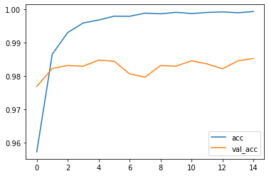

```python
# Accuracy plot
create_accuracy_plot_per_iteration(r4)
```

Confusion matrix and missclassfied examples

```python
y_pred = get_confusion_matrix(model4)
```

```
[0.09968660026788712, 0.9851999878883362]
               Predicted Label
[[ 975    0    1    0    0    0    3    1    0    0]
 [   0 1126    2    2    0    1    2    1    1    0]
 [   1    0 1018    0    0    0    1    6    4    2]
 [   0    0    0  993    0    5    0    4    6    2]
 [   0    0    3    0  965    0    5    0    1    8]
 [   0    0    1    6    0  879    6    0    0    0]
 [   2    2    0    1    2    1  948    0    2    0]
 [   0    1   12    1    0    0    0 1006    2    6]
 [   3    1    4    1    0    2    0    3  955    5]
 [   1    3    1    2    9    3    0    0    3  987]]
```

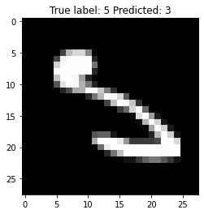

```python
# Show missclassified examples
show_missclassified_images(y_pred)
```

**Model 5 - two conv-pools with two strided convolution layer**

```python
from typing import Sized
# 64 - No of feature maps (changes with each conv layer)
# MaxPolling2D
# When we go from input layer to first ouput the depth is 1
# 5,5 - filter Size
# padding = same (no padding)

# Stage1
i = Input(shape=x_train[0].shape)
x = Conv2D(64, (5, 5),strides=2, activation='relu', padding='same')(i)
x = Conv2D(128, (5, 5),strides=2, activation='relu', padding='same')(x)

#Stage2
x = Flatten()(x)
x = Dense(512, activation='relu')(x)
x = Dense(K, activation='softmax')(x)

model5 = Model(i, x)

model5.summary()
```

```
Model: "model_4"
_________________________________________________________________
 Layer (type)                Output Shape              Param #
=================================================================
 input_5 (InputLayer)        [(None, 28, 28, 1)]       0

 conv2d_8 (Conv2D)           (None, 14, 14, 64)        1664

 conv2d_9 (Conv2D)           (None, 7, 7, 128)         204928

 flatten_4 (Flatten)         (None, 6272)              0

 dense_8 (Dense)             (None, 512)               3211776

 dense_9 (Dense)             (None, 10)                5130

=================================================================
Total params: 3,423,498
Trainable params: 3,423,498
Non-trainable params: 0
_________________________________________________________________
```

Model compilation and loss/accuracy plots

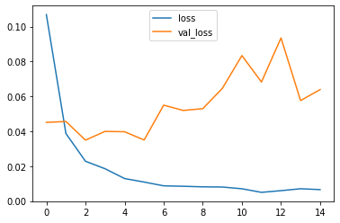

```python
# Model compile and fit
r5 = compile_model(model5)

# Loss plot
create_loss_plot_per_iteration(r5)
```

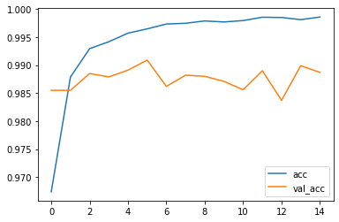

```python
# Accuracy plot
create_accuracy_plot_per_iteration(r5)
```

Confusion matrix and missclassfied examples

```python
y_pred = get_confusion_matrix(model5)
```

```
[0.06392952799797058, 0.9886999726295471]
               Predicted Label
[[ 977    1    1    0    0    0    0    1    0    0]
 [   0 1129    1    3    0    0    1    1    0    0]
 [   1    0 1027    0    0    0    0    2    2    0]
 [   0    0    7  988    0    4    0    5    1    5]
 [   0    0    1    0  966    0    3    0    1   11]
 [   2    0    0    7    0  878    2    1    0    2]
 [   4    2    2    1    0    2  947    0    0    0]
 [   0    2   12    0    0    0    0 1011    0    3]
 [   1    0    1    1    1    2    0    1  962    5]
 [   0    0    1    0    4    1    0    0    1 1002]]
```

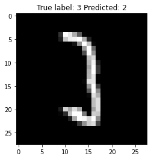

```python
# Show missclassified examples
show_missclassified_images(y_pred)
```

**Model 5 summary:** Model 5 with convoloution layer gives test accuracy of 98.87% with loss at 0.06. As per loss plot, trainining loss starts plateauing from 3rd epoch but validation loss starts increasing, hence model is becoming overfit and not stable due to fluctuation. As per accuracy plot, both training and validation accuracy starts plateauing from 3rd epoch. Both model5 and model2 gives loss at 0.06 but model2 is more generalized thann model5.

```python
from typing import Sized
# 64 - No of feature maps (changes with each conv layer)
# MaxPolling2D
# When we go from input layer to first ouput the depth is 1
# 5,5 - filter Size
# padding = same (no padding)

# Stage1
i = Input(shape=x_train[0].shape)
x = Conv2D(64, (5, 5), activation='relu', strides=2, padding='same')(i)
x = Conv2D(128, (5, 5), activation='relu', strides=2, padding='same')(x)
x = Conv2D(256, (5, 5), activation='relu', strides=2, padding='same')(x)
x = Conv2D(512, (5, 5), activation='relu', strides=2, padding='same')(x)

#Stage2
x = Flatten()(x)
x = Dropout(0.2)(x)
x = Dense(512, activation='relu')(x)
x = Dropout(0.2)(x)
x = Dense(1024, activation='relu')(x)
x = Dropout(0.2)(x)
x = Dense(K, activation='softmax')(x)

model6 = Model(i, x)

model6.summary()
```

```
Model: "model_5"
_________________________________________________________________
 Layer (type)                Output Shape              Param #
=================================================================
 input_6 (InputLayer)        [(None, 28, 28, 1)]       0

 conv2d_10 (Conv2D)          (None, 14, 14, 64)        1664

 conv2d_11 (Conv2D)          (None, 7, 7, 128)         204928

 conv2d_12 (Conv2D)          (None, 4, 4, 256)         819456

 conv2d_13 (Conv2D)          (None, 2, 2, 512)         3277312

 flatten_5 (Flatten)         (None, 2048)              0

 dropout_2 (Dropout)         (None, 2048)              0

 dense_10 (Dense)            (None, 512)               1049088

 dropout_3 (Dropout)         (None, 512)               0

 dense_11 (Dense)            (None, 1024)              525312

 dropout_4 (Dropout)         (None, 1024)              0

 dense_12 (Dense)            (None, 10)                10250

=================================================================
Total params: 5,888,010
Trainable params: 5,888,010
Non-trainable params: 0
_________________________________________________________________
```

Model compilation and loss/accuracy plots

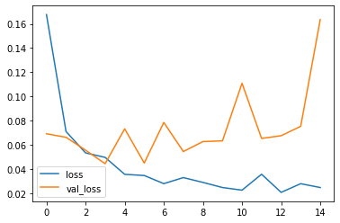

```python
# Model compile and fit
r6 = compile_model(model6)

# Loss plot
create_loss_plot_per_iteration(r6)
```

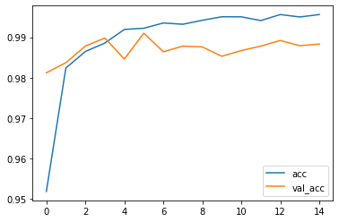

```python
# Accuracy plot
create_accuracy_plot_per_iteration(r6)
```

Confusion matrix and missclassfied examples

```python
y_pred = get_confusion_matrix(model6)
```

```
[0.16350774466991425, 0.9883000254631042]
               Predicted Label
[[ 979    0    0    0    0    0    0    1    0    0]
 [   2 1130    0    0    0    1    1    1    0    0]
 [   1    0 1026    0    0    0    0    4    1    0]
 [   0    0    1  999    0    7    0    2    1    0]
 [   1    1    4    0  945    0    4    0    2   25]
 [   1    0    0    4    0  884    1    0    0    2]
 [   5    2    0    0    1    1  948    0    1    0]
 [   0    2    7    0    0    0    0 1019    0    0]
 [   1    0    4    1    0    3    0    1  957    7]
 [   0    1    0    0    2    9    0    1    0  996]]
```

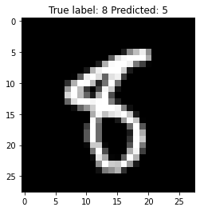

```python
# Show missclassified examples
show_missclassified_images(y_pred)
```

**Image Data Augmentation**

Best performing model is model 3. Hence using model 3 for building model 7 (with batch normalization) and model 8 (with image data augmentation).

**Model 7** - Modifying model3 with batch normalozation

```python
from typing import Sized
# 256 - No of feature maps (changes with each conv layer)
# MaxPolling2D
# 3,3 - filter Size
# padding = same (no padding)

# Stage1
i = Input(shape=x_train[0].shape)
x = Conv2D(32, (3, 3), activation='relu', padding='same')(i)
x = BatchNormalization()(x)
x = Conv2D(64, (3, 3), activation='relu', padding='same')(x)
x = BatchNormalization()(x)
x = MaxPooling2D((2,2))(x)
x = Conv2D(128, (3, 3), activation='relu', padding='same')(x)
x = BatchNormalization()(x)
x = Conv2D(256, (3, 3), activation='relu', padding='same')(x)
x = BatchNormalization()(x)
x = MaxPooling2D((2,2))(x)

#Stage2
x = Flatten()(x)
x = Dropout(0.2)(x)
x = Dense(512, activation='relu')(x)
x = Dropout(0.2)(x)
x = Dense(K, activation='softmax')(x)

model7 = Model(i, x)

model7.summary()
```

```
Model: "model_6"
_________________________________________________________________
 Layer (type)                Output Shape              Param #
=================================================================
 input_7 (InputLayer)        [(None, 28, 28, 1)]       0

 conv2d_14 (Conv2D)          (None, 28, 28, 32)        320

 batch_normalization (BatchN  (None, 28, 28, 32)       128
 ormalization)

 conv2d_15 (Conv2D)          (None, 28, 28, 64)        18496

 batch_normalization_1 (Batc  (None, 28, 28, 64)       256
 hNormalization)

 max_pooling2d_7 (MaxPooling  (None, 14, 14, 64)       0
 2D)

 conv2d_16 (Conv2D)          (None, 14, 14, 128)       73856

 batch_normalization_2 (Batc  (None, 14, 14, 128)      512
 hNormalization)

 conv2d_17 (Conv2D)          (None, 14, 14, 256)       295168

 batch_normalization_3 (Batc  (None, 14, 14, 256)      1024
 hNormalization)

 max_pooling2d_8 (MaxPooling  (None, 7, 7, 256)        0
 2D)

 flatten_6 (Flatten)         (None, 12544)             0

 dropout_5 (Dropout)         (None, 12544)             0

 dense_13 (Dense)            (None, 512)               6423040

 dropout_6 (Dropout)         (None, 512)               0

 dense_14 (Dense)            (None, 10)                5130

=================================================================
Total params: 6,817,930
Trainable params: 6,816,970
Non-trainable params: 960
_________________________________________________________________
```

Model compilation and loss/accuracy plots

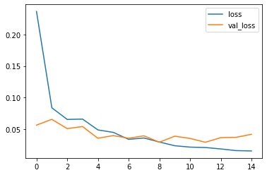

```python
# Model compile and fit
r7 = compile_model(model7)

# Loss plot
create_loss_plot_per_iteration(r7)
```

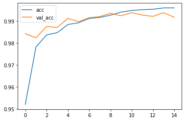

```python
# Accuracy plot
create_accuracy_plot_per_iteration(r7)
```

Confusion matrix and missclassfied examples

```python
y_pred = get_confusion_matrix(model7)
```

```
[0.0416942797601223, 0.9918000102043152]
               Predicted Label
[[ 977    0    0    0    0    0    1    0    0    2]
 [   0 1131    0    2    0    0    0    2    0    0]
 [   0    0 1023    2    0    0    0    7    0    0]
 [   0    0    0 1005    0    5    0    0    0    0]
 [   0    0    0    0  975    0    0    1    0    6]
 [   0    0    0    4    0  886    1    1    0    0]
 [   3    3    1    0    2    4  945    0    0    0]
 [   0    3    2    0    0    0    0 1022    0    1]
 [   3    1    2    2    1    7    0    0  952    6]
 [   0    0    0    0    4    3    0    0    0 1002]]
```

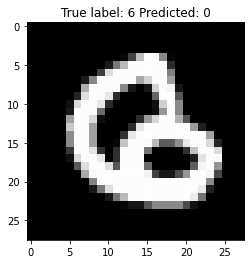

```python
# Show missclassified examples
show_missclassified_images(y_pred)
```

**Model 8 - Modifying model 3 with image data augmentation**

```python
batch_size = 32
data_generator = tf.keras.preprocessing.image.ImageDataGenerator(
      width_shift_range = 0.1,
      height_shift_range=0.1,
      horizontal_flip=True
)
train_generator = data_generator.flow(x_train,y_train,batch_size)
steps_per_epoch = x_train.shape[0] // batch_size
```

```python
from typing import Sized
# 256 - No of feature maps (changes with each conv layer)
# MaxPolling2D
# 3,3 - filter Size
# padding = same (no padding)

# Stage1
i = Input(shape=x_train[0].shape)
x = Conv2D(32, (3, 3), activation='relu', padding='same')(i)
x = MaxPooling2D((2,2))(x)
x = Conv2D(64, (3, 3), activation='relu', padding='same')(x)
x = MaxPooling2D((2,2))(x)
x = Conv2D(128, (3, 3), activation='relu', padding='same')(x)
x = MaxPooling2D((2,2))(x)
x = Conv2D(256, (3, 3), activation='relu', padding='same')(x)
x = MaxPooling2D((2,2))(x)

#Stage2
x = Flatten()(x)
x = Dropout(0.2)(x)
x = Dense(512, activation='relu')(x)
x = Dropout(0.2)(x)
x = Dense(K, activation='softmax')(x)

model8 = Model(i, x)

model8.summary()
```

```
Model: "model_7"
_________________________________________________________________
 Layer (type)                Output Shape              Param #
=================================================================
 input_8 (InputLayer)        [(None, 28, 28, 1)]       0

 conv2d_18 (Conv2D)          (None, 28, 28, 32)        320

 max_pooling2d_9 (MaxPooling  (None, 14, 14, 32)       0
 2D)

 conv2d_19 (Conv2D)          (None, 14, 14, 64)        18496

 max_pooling2d_10 (MaxPoolin  (None, 7, 7, 64)         0
 g2D)

 conv2d_20 (Conv2D)          (None, 7, 7, 128)         73856

 max_pooling2d_11 (MaxPoolin  (None, 3, 3, 128)        0
 g2D)

 conv2d_21 (Conv2D)          (None, 3, 3, 256)         295168

 max_pooling2d_12 (MaxPoolin  (None, 1, 1, 256)        0
 g2D)

 flatten_7 (Flatten)         (None, 256)               0

 dropout_7 (Dropout)         (None, 256)               0

 dense_15 (Dense)            (None, 512)               131584

 dropout_8 (Dropout)         (None, 512)               0

 dense_16 (Dense)            (None, 10)                5130

=================================================================
Total params: 524,554
Trainable params: 524,554
Non-trainable params: 0
_________________________________________________________________
```

Model compilation and loss/accuracy plots

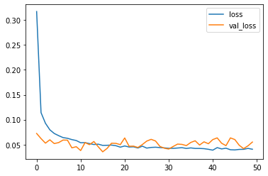

```python
# Model compile and fit
model8.compile(optimizer='adam',
                loss='sparse_categorical_crossentropy',
                metrics=['accuracy'])

r8 = model8.fit(train_generator,
               validation_data = (x_test,y_test),
               steps_per_epoch=steps_per_epoch,
               epochs=50)

# Loss plot
create_loss_plot_per_iteration(r8)
```

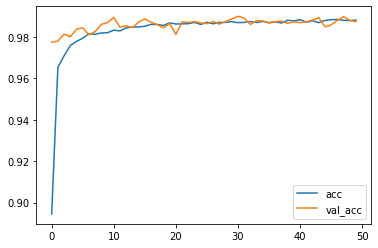

```python
# Accuracy plot
create_accuracy_plot_per_iteration(r8)
```

```python
y_pred = get_confusion_matrix(model8)
```

```
[0.05506325140595436, 0.987500011920929]
               Predicted Label
[[ 977    0    0    0    0    0    1    0    1    1]
 [   0 1134    0    1    0    0    0    0    0    0]
 [   2    1  997    1    2   13   11    3    2    0]
 [   0    0    1 1007    0    1    1    0    0    0]
 [   0    0    0    0  976    0    1    0    0    5]
 [   1    1   16    5    0  864    2    3    0    0]
 [   6    0    2    0    0    2  947    0    1    0]
 [   0   10    3    1    2    1    0 1010    0    1]
 [   2    0    0    1    0    2    1    0  965    3]
 [   1    0    1    0    3    1    0    2    3  998]]
```

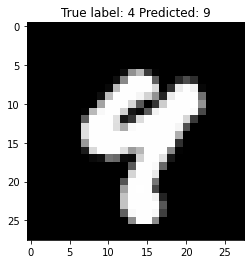

```python
# Show missclassified examples
show_missclassified_images(y_pred)
```

**Model 8 summary:** Model 8 with image data augmentation gives test accuracy of 98.75% with loss at 0.05. As per loss plot, trainining loss and validation loass starts plateauing from 4-5 epoch. Although is not minimed further as compared to model 3 but accuracy and loss plots are more smooth and better generalize the result.